# Análise Comparativa: Gasto por Aluno (SIOPE vs. SICONFI)

Municípios Selecionados (2015-2023)

Rafael Abreu

## 1. Configuração do Ambiente

Carrega pacotes. O `tidyverse` é uma coleção de pacotes que inclui o `dplyr` (para manipulação de dados) e o `ggplot2` (para gráficos). O `knitr` e `kableExtra` ajudam a formatar tabelas.

```r
# Instale os pacotes se ainda não os tiver
# install.packages("tidyverse")
# install.packages("knitr")
# install.packages("kableExtra")
#install.packages("patchwork")

library(tidyverse)  # Pacote principal para manipulação e gráficos
library(knitr)      # Para formatar tabelas
library(kableExtra) # Funções extras para tabelas
library(patchwork)
```

## 2. Carga e Preparação dos Dados

```r
dados <- readxl::read_excel("dados_mucuri.xlsx", sheet = "gasto")

# Visualizar os primeiros dados
kable(head(dados), caption = "Amostra dos Dados Carregados") %>%
  kable_styling(bootstrap_options = "striped", full_width = F)
```

Amostra dos Dados Carregados

| ano | id_ente | nom_munic | gasto_aluno_SIOPE | gasto_aluno_SICONFI | populacao | tamanho |
| --- | --- | --- | --- | --- | --- | --- |
| 2015 | 3100906 | Águas Formosas | 10390.98 | 10475.499 | 19248 | Médio |
| 2015 | 3104700 | Ataléia | 7240.53 | 9064.471 | 14188 | Médio |
| 2015 | 3113701 | Carlos Chagas | 5643.97 | 5293.363 | 20090 | Médio |
| 2015 | 3126802 | Frei Gaspar | 5474.87 | 5733.405 | 6031 | Pequeno |
| 2015 | 3127057 | Fronteira dos Vales | 8410.91 | 6090.194 | 4765 | Pequeno |
| 2015 | 3132305 | Itaipé | 5278.54 | 5769.405 | 12489 | Médio |

### 2.1. Criando Campos Calculados

Colunas de diferença.

- `diff_abs` (Diferença Absoluta): SIOPE - SICONFI
- `diff_perc` (Diferença Percentual): A diferença como uma porcentagem do valor do SICONFI.

```r
dados <- dados %>%
  mutate(
    diff_abs = gasto_aluno_SIOPE - gasto_aluno_SICONFI,
    diff_perc = (diff_abs / gasto_aluno_SICONFI) * 100
  )

kable(head(dados), caption = "Amostra dos Dados com Campos Calculados") %>%
  kable_styling(bootstrap_options = "striped", full_width = F)
```

Amostra dos Dados com Campos Calculados

| ano | id_ente | nom_munic | gasto_aluno_SIOPE | gasto_aluno_SICONFI | populacao | tamanho | diff_abs | diff_perc |
| --- | --- | --- | --- | --- | --- | --- | --- | --- |
| 2015 | 3100906 | Águas Formosas | 10390.98 | 10475.499 | 19248 | Médio | -84.51872 | -0.8068229 |
| 2015 | 3104700 | Ataléia | 7240.53 | 9064.471 | 14188 | Médio | -1823.94066 | -20.1218662 |
| 2015 | 3113701 | Carlos Chagas | 5643.97 | 5293.363 | 20090 | Médio | 350.60674 | 6.6235155 |
| 2015 | 3126802 | Frei Gaspar | 5474.87 | 5733.405 | 6031 | Pequeno | -258.53459 | -4.5092682 |
| 2015 | 3127057 | Fronteira dos Vales | 8410.91 | 6090.194 | 4765 | Pequeno | 2320.71614 | 38.1057844 |
| 2015 | 3132305 | Itaipé | 5278.54 | 5769.405 | 12489 | Médio | -490.86490 | -8.5080682 |

## 3. Análise Descritiva Geral

```r
# Gasto e diferença
estatisticas_gerais <- dados %>%
  select(gasto_aluno_SIOPE, gasto_aluno_SICONFI, diff_abs, diff_perc) %>%
  summary()

# Sumário
print(estatisticas_gerais)
```

```
##  gasto_aluno_SIOPE gasto_aluno_SICONFI    diff_abs          diff_perc
##  Min.   : 4787     Min.   : 3367       Min.   :-19219.4   Min.   :-57.192
##  1st Qu.: 6331     1st Qu.: 7006       1st Qu.: -1906.3   1st Qu.:-18.113
##  Median : 8429     Median : 8981       Median :  -863.0   Median : -8.921
##  Mean   : 9297     Mean   :10518       Mean   : -1221.3   Mean   : -6.328
##  3rd Qu.:11395     3rd Qu.:12758       3rd Qu.:   150.6   3rd Qu.:  1.735
##  Max.   :18700     Max.   :36201       Max.   :  7135.4   Max.   :211.916
```

Desvio padrão (sd) e coeficiente de variação (cv).

```r
dados %>%
  summarise(
    Fonte = "Geral",
    Media_SIOPE = mean(gasto_aluno_SIOPE, na.rm = TRUE),
    Media_SICONFI = mean(gasto_aluno_SICONFI, na.rm = TRUE),
    Media_Diff_Abs = mean(diff_abs, na.rm = TRUE),
    SD_Diff_Abs = sd(diff_abs, na.rm = TRUE),
    CV_Diff_Abs = (SD_Diff_Abs / Media_Diff_Abs) * 100,
    Media_Diff_Perc = mean(diff_perc, na.rm = TRUE),
    SD_Diff_Perc = sd(diff_perc, na.rm = TRUE)
  ) %>%
  kable(caption = "Estatísticas Descritivas Gerais (2015-2023)", digits = 2) %>%
  kable_styling(bootstrap_options = "striped", full_width = T)
```

Estatísticas Descritivas Gerais (2015-2023)

| Fonte | Media_SIOPE | Media_SICONFI | Media_Diff_Abs | SD_Diff_Abs | CV_Diff_Abs | Media_Diff_Perc | SD_Diff_Perc |
| --- | --- | --- | --- | --- | --- | --- | --- |
| Geral | 9297.19 | 10518.45 | -1221.26 | 2991.44 | -244.95 | -6.33 | 27.08 |

### 3.1. Visualização da Distribuição Geral

As tabelas de resumo acima mostram que a diferença média não é zero. Os gráficos de densidade abaixo nos ajudam a visualizar a distribuição completa dessas diferenças.

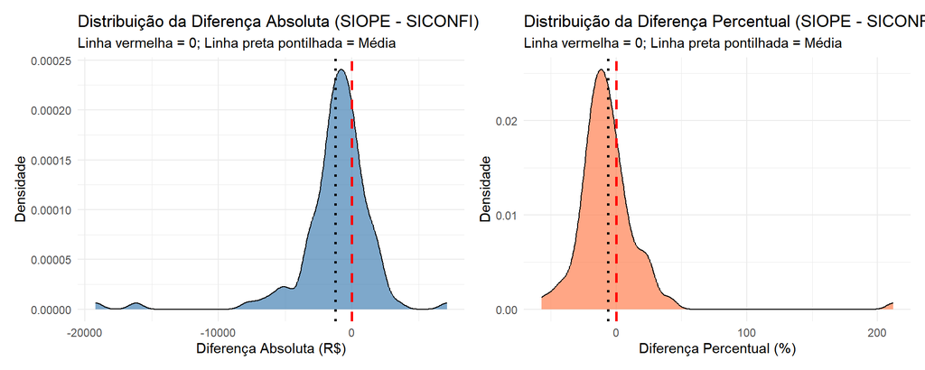

```r
# Gráfico para a Diferença Absoluta
p1 <- ggplot(dados, aes(x = diff_abs)) +
  geom_density(fill = "steelblue", alpha = 0.7) +
  geom_vline(xintercept = 0, linetype = "dashed", color = "red", linewidth = 1) +
  geom_vline(aes(xintercept = mean(diff_abs)), linetype = "dotted", color = "black", linewidth = 1) +
  labs(
    title = "Distribuição da Diferença Absoluta (SIOPE - SICONFI)",
    subtitle = "Linha vermelha = 0; Linha preta pontilhada = Média",
    x = "Diferença Absoluta (R$)",
    y = "Densidade"
  ) +
  theme_minimal()

# Gráfico para a Diferença Percentual
p2 <- ggplot(dados, aes(x = diff_perc)) +
  geom_density(fill = "coral", alpha = 0.7) +
  geom_vline(xintercept = 0, linetype = "dashed", color = "red", linewidth = 1) +
  geom_vline(aes(xintercept = mean(diff_perc)), linetype = "dotted", color = "black", linewidth = 1) +
  labs(
    title = "Distribuição da Diferença Percentual (SIOPE - SICONFI)",
    subtitle = "Linha vermelha = 0; Linha preta pontilhada = Média",
    x = "Diferença Percentual (%)",
    y = "Densidade"
  ) +
  theme_minimal()

# (Opcional, mas útil) Instalar o 'patchwork' para mostrar lado a lado
# install.packages("patchwork")
# library(patchwork)
  p1 + p2
```

```r
# Se não tiver o patchwork, o Rmd vai mostrá-los um após o outro.
#print(p1)
#print(p2)
```

### 3.2. Visualização: Boxplots (Resumo Estatístico)

Os boxplots abaixo são a visualização direta da tabela `summary()`. Eles mostram os quartis, medianas e outliers para os gastos e suas diferenças.

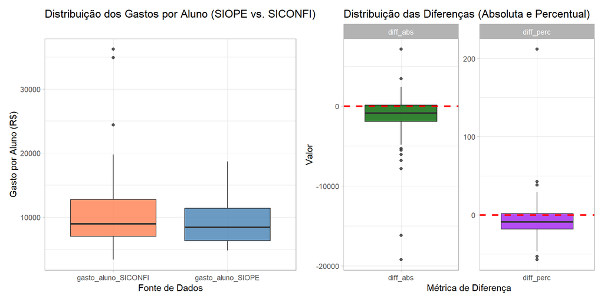

```r
# --- GRÁFICO 1: Boxplot dos Níveis de Gasto ---
dados_long_gasto <- dados %>%
  select(gasto_aluno_SIOPE, gasto_aluno_SICONFI) %>%
  pivot_longer(
    cols = c(gasto_aluno_SIOPE, gasto_aluno_SICONFI),
    names_to = "Fonte",
    values_to = "Gasto_por_Aluno"
  )

b1 <- ggplot(dados_long_gasto, aes(x = Fonte, y = Gasto_por_Aluno, fill = Fonte)) +
  geom_boxplot(alpha = 0.8) +
  scale_fill_manual(values = c("gasto_aluno_SIOPE" = "steelblue", "gasto_aluno_SICONFI" = "coral")) +
  labs(title = "Distribuição dos Gastos por Aluno (SIOPE vs. SICONFI)",
       x = "Fonte de Dados",
       y = "Gasto por Aluno (R$)") +
  theme_light() +
  theme(legend.position = "none")

# --- GRÁFICO 2: Boxplot das Diferenças ---
dados_long_diff <- dados %>%
  select(diff_abs, diff_perc) %>%
  pivot_longer(
    cols = c(diff_abs, diff_perc),
    names_to = "Metrica_Diferenca",
    values_to = "Valor"
  )

b2 <- ggplot(dados_long_diff, aes(x = Metrica_Diferenca, y = Valor, fill = Metrica_Diferenca)) +
  geom_boxplot(alpha = 0.8, show.legend = FALSE) +
  geom_hline(yintercept = 0, linetype = "dashed", color = "red", linewidth = 1) +
  facet_wrap(~ Metrica_Diferenca, scales = "free") + # scales = "free" é crucial
  scale_fill_manual(values = c("diff_abs" = "darkgreen", "diff_perc" = "purple")) +
  labs(title = "Distribuição das Diferenças (Absoluta e Percentual)",
       x = "Métrica de Diferença",
       y = "Valor") +
  theme_light()

# Mostra os dois gráficos lado a lado
b1 + b2
```

### 3.3. Visualização: Outras Comparações (ECDF)

Além dos boxplots, um gráfico de **ECDF (Função de Distribuição Cumulativa Empírica)** é uma excelente forma de comparar as duas distribuições de gastos (SIOPE vs. SICONFI).

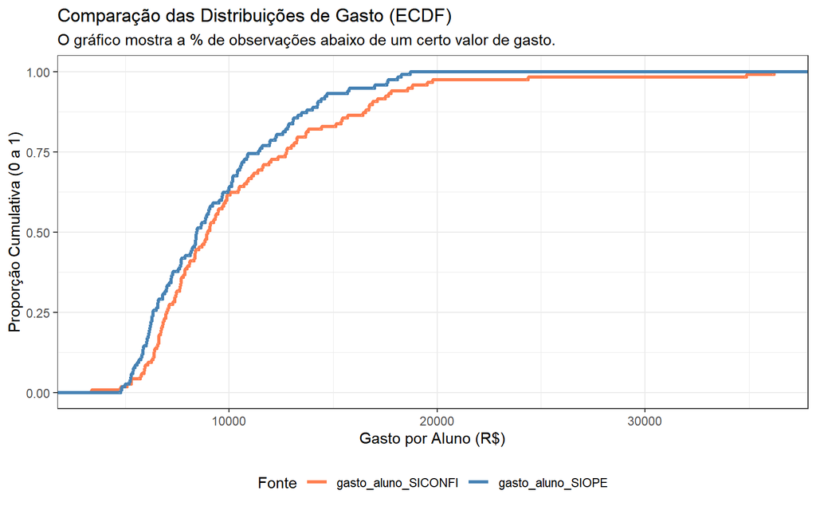

```r
#dados 'dados_long_gasto' criados no bloco anterior
ggplot(dados_long_gasto, aes(x = Gasto_por_Aluno, color = Fonte)) +
  stat_ecdf(linewidth = 1.2) + # A função principal do ECDF
  scale_color_manual(values = c("gasto_aluno_SIOPE" = "steelblue", "gasto_aluno_SICONFI" = "coral")) +
  labs(
    title = "Comparação das Distribuições de Gasto (ECDF)",
    subtitle = "O gráfico mostra a % de observações abaixo de um certo valor de gasto.",
    x = "Gasto por Aluno (R$)",
    y = "Proporção Cumulativa (0 a 1)"
  ) +
  theme_bw() +
  theme(legend.position = "bottom")
```

## 4. Análise por Município

Comportamento médio de cada município ao longo do período.

### 4.1. Tabela por Município

Diferença absoluta média para cada município.

```r
analise_municipio <- dados %>%
  group_by(nom_munic, id_ente) %>%
  summarise(
    tamanho = first(tamanho), # Adicionado para usar no gráfico abaixo
    Media_SIOPE = mean(gasto_aluno_SIOPE, na.rm = TRUE),
    Media_SICONFI = mean(gasto_aluno_SICONFI, na.rm = TRUE),
    Media_Diff_Abs = mean(diff_abs, na.rm = TRUE),
    SD_Diff_Abs = sd(diff_abs, na.rm = TRUE),
    Media_Diff_Perc = mean(diff_perc, na.rm = TRUE)
  ) %>%
  arrange(desc(Media_Diff_Abs)) # Ordenar pela maior diferença

kable(analise_municipio,
      caption = "Diferença Média (SIOPE - SICONFI) por Município (2015-2023)",
      digits = 2) %>%
  kable_styling(bootstrap_options = c("striped", "hover"), full_width = F)
```

Diferença Média (SIOPE - SICONFI) por Município (2015-2023)

| nom_munic | id_ente | tamanho | Media_SIOPE | Media_SICONFI | Media_Diff_Abs | SD_Diff_Abs | Media_Diff_Perc |
| --- | --- | --- | --- | --- | --- | --- | --- |
| Fronteira dos Vales | 3127057 | Pequeno | 10200.96 | 9849.83 | 351.13 | 1463.86 | 8.68 |
| Nanuque | 3144300 | Grande | 9545.83 | 9667.45 | -121.62 | 1818.95 | 0.68 |
| Teófilo Otoni | 3168606 | Grande | 7530.26 | 7831.74 | -301.48 | 972.06 | -2.50 |
| Frei Gaspar | 3126802 | Pequeno | 9011.35 | 9365.29 | -353.93 | 2988.79 | 12.43 |
| Novo Oriente de Minas | 3145356 | Médio | 10026.97 | 10404.65 | -377.67 | 1292.10 | -4.27 |
| Umburatiba | 3170305 | Pequeno | 9206.13 | 9748.87 | -542.74 | 1208.44 | -3.82 |
| Carlos Chagas | 3113701 | Médio | 7630.86 | 8358.63 | -727.77 | 817.73 | -8.06 |
| Poté | 3152402 | Médio | 7245.03 | 8414.68 | -1169.65 | 1302.27 | -11.78 |
| Ataléia | 3104700 | Médio | 11221.78 | 12393.40 | -1171.62 | 1847.07 | -8.18 |
| Santa Helena de Minas | 3157658 | Pequeno | 10042.50 | 11261.41 | -1218.91 | 2590.72 | -5.37 |
| Malacacheta | 3139201 | Médio | 9977.48 | 11686.55 | -1709.08 | 2519.37 | -12.11 |
| Itaipé | 3132305 | Médio | 7595.97 | 9630.33 | -2034.36 | 2104.37 | -18.09 |
| Águas Formosas | 3100906 | Médio | 11628.39 | 18127.08 | -6498.69 | 6939.09 | -29.88 |

#### 4.1.1. Gráfico: “Gap” Médio por Município e Tamanho (Dumbbell Plot)

O gráfico de halteres (dumbbell plot) abaixo é uma forma “menos usual” e muito eficaz de visualizar o “gap” entre as duas fontes (SIOPE e SICONFI) para cada município. Ele é uma visualização direta da tabela acima, mas agrupado por porte.

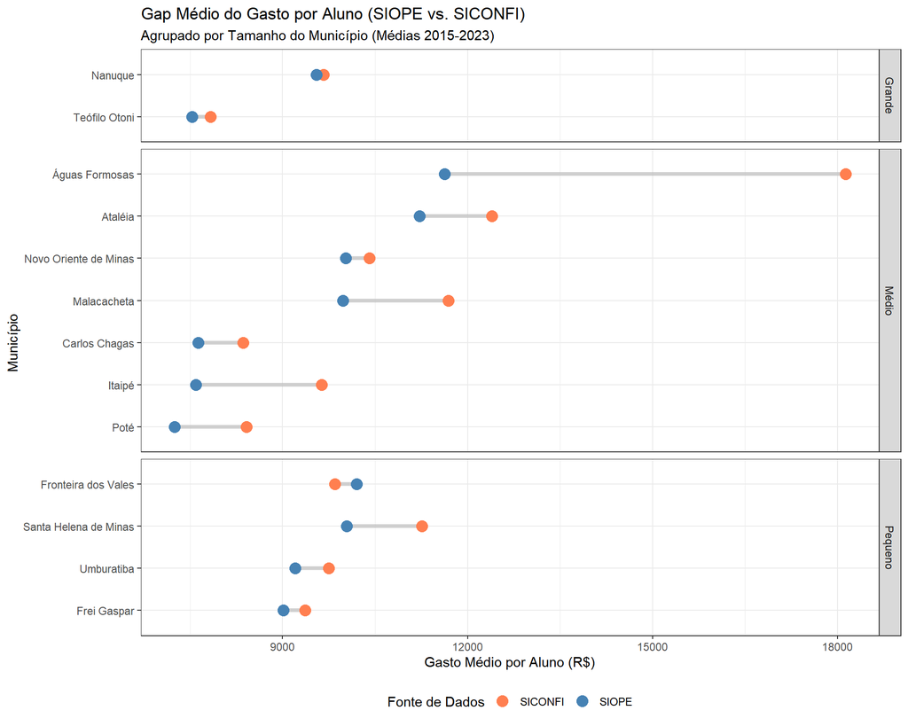

```r
# Carregar o pacote ggalt (precisa instalar: install.packages("ggalt"))
# library(ggalt)
# Se não puder/quiser usar ggalt, podemos usar geom_segment

ggplot(analise_municipio, aes(y = fct_reorder(nom_munic, Media_SIOPE),
                             x = Media_SICONFI, xend = Media_SIOPE)) +
  # Este geom_segment cria a "barra" do haltere
  geom_segment(aes(yend = fct_reorder(nom_munic, Media_SIOPE)),
               color = "grey", linewidth = 1.5, alpha = 0.7) +
  # Pontos para SICONFI e SIOPE
  geom_point(aes(color = "SICONFI"), size = 4) +
  geom_point(aes(x = Media_SIOPE, color = "SIOPE"), size = 4) +
  # Agrupa por tamanho
  facet_grid(tamanho ~ ., scales = "free_y", space = "free_y") +
  scale_color_manual(values = c("SIOPE" = "steelblue", "SICONFI" = "coral")) +
  labs(
    title = "Gap Médio do Gasto por Aluno (SIOPE vs. SICONFI)",
    subtitle = "Agrupado por Tamanho do Município (Médias 2015-2023)",
    x = "Gasto Médio por Aluno (R$)",
    y = "Município",
    color = "Fonte de Dados"
  ) +
  theme_bw() +
  theme(legend.position = "bottom")
```

### 4.2. Gráfico: Séries Temporais por Município

```r
dados_long <- dados %>%
  pivot_longer(
    cols = c(gasto_aluno_SIOPE, gasto_aluno_SICONFI),
    names_to = "Fonte",
    values_to = "Gasto_por_Aluno"
  )

# Amostra dos dados "longos"
kable(head(dados_long), caption = "Dados em Formato Longo (para Gráficos)") %>%
  kable_styling(bootstrap_options = "striped", full_width = F)
```

Dados em Formato Longo (para Gráficos)

| ano | id_ente | nom_munic | populacao | tamanho | diff_abs | diff_perc | Fonte | Gasto_por_Aluno |
| --- | --- | --- | --- | --- | --- | --- | --- | --- |
| 2015 | 3100906 | Águas Formosas | 19248 | Médio | -84.51872 | -0.8068229 | gasto_aluno_SIOPE | 10390.980 |
| 2015 | 3100906 | Águas Formosas | 19248 | Médio | -84.51872 | -0.8068229 | gasto_aluno_SICONFI | 10475.499 |
| 2015 | 3104700 | Ataléia | 14188 | Médio | -1823.94066 | -20.1218662 | gasto_aluno_SIOPE | 7240.530 |
| 2015 | 3104700 | Ataléia | 14188 | Médio | -1823.94066 | -20.1218662 | gasto_aluno_SICONFI | 9064.471 |
| 2015 | 3113701 | Carlos Chagas | 20090 | Médio | 350.60674 | 6.6235155 | gasto_aluno_SIOPE | 5643.970 |
| 2015 | 3113701 | Carlos Chagas | 20090 | Médio | 350.60674 | 6.6235155 | gasto_aluno_SICONFI | 5293.363 |

Agora, vamos gerar o gráfico facetado (em painéis).

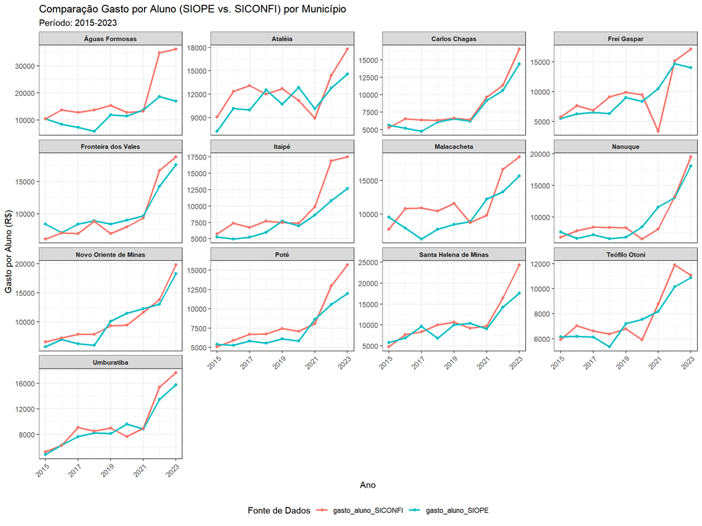

```r
ggplot(dados_long, aes(x = ano, y = Gasto_por_Aluno, color = Fonte, group = Fonte)) +
  geom_line(linewidth = 1) +
  geom_point() +
  facet_wrap(~ nom_munic, scales = "free_y", ncol = 4) +
  labs(
    title = "Comparação Gasto por Aluno (SIOPE vs. SICONFI) por Município",
    subtitle = "Período: 2015-2023",
    x = "Ano",
    y = "Gasto por Aluno (R$)",
    color = "Fonte de Dados"
  ) +
  scale_x_continuous(breaks = seq(2015, 2023, by = 2)) +
  theme_bw() + # Tema limpo
  theme(
    legend.position = "bottom",
    strip.text = element_text(size = 8, face = "bold"), # Nomes dos municípios
    axis.text.x = element_text(angle = 45, hjust = 1)
  )
```

#### 4.2.1. Gráfico: Evolução da Diferença Percentual

O gráfico acima mostra os níveis de gasto, mas não a diferença. O gráfico abaixo foca em plotar a `diff_perc` ao longo do tempo. Isso nos ajuda a ver se a discrepância entre as fontes está aumentando ou diminuindo.

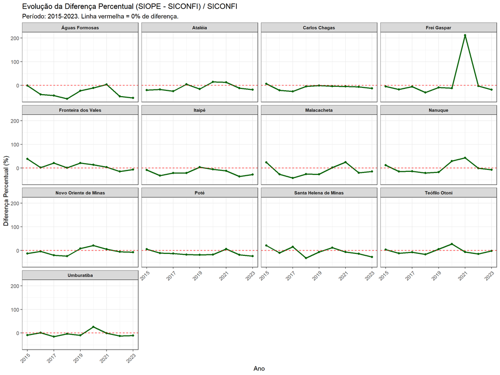

```r
ggplot(dados, aes(x = ano, y = diff_perc)) +
  geom_line(color = "darkgreen", linewidth = 1) +
  geom_point(color = "darkgreen") +
  geom_hline(yintercept = 0, linetype = "dashed", color = "red") +
  facet_wrap(~ nom_munic, ncol = 4) +
  labs(
    title = "Evolução da Diferença Percentual (SIOPE - SICONFI) / SICONFI",
    subtitle = "Período: 2015-2023. Linha vermelha = 0% de diferença.",
    x = "Ano",
    y = "Diferença Percentual (%)"
  ) +
  scale_x_continuous(breaks = seq(2015, 2023, by = 2)) +
  theme_bw() +
  theme(
    strip.text = element_text(size = 8, face = "bold"),
    axis.text.x = element_text(angle = 45, hjust = 1)
  )
```

## 5. Análise por Cluster (Tamanho do Município)

### 5.1. Tabela por Tamanho

```r
analise_tamanho <- dados %>%
  group_by(tamanho) %>%
  summarise(
    N_Obs = n(),
    Media_SIOPE = mean(gasto_aluno_SIOPE, na.rm = TRUE),
    Media_SICONFI = mean(gasto_aluno_SICONFI, na.rm = TRUE),
    Media_Diff_Abs = mean(diff_abs, na.rm = TRUE),
    SD_Diff_Abs = sd(diff_abs, na.rm = TRUE),
    Media_Diff_Perc = mean(diff_perc, na.rm = TRUE)
  ) %>%
  arrange(desc(Media_Diff_Abs))

kable(analise_tamanho,
      caption = "Análise da Diferença Média por Tamanho do Município",
      digits = 2) %>%
  kable_styling(bootstrap_options = "striped", full_width = F)
```

Análise da Diferença Média por Tamanho do Município

| tamanho | N_Obs | Media_SIOPE | Media_SICONFI | Media_Diff_Abs | SD_Diff_Abs | Media_Diff_Perc |
| --- | --- | --- | --- | --- | --- | --- |
| Grande | 18 | 8538.04 | 8749.59 | -211.55 | 1417.82 | -0.91 |
| Pequeno | 36 | 9615.24 | 10056.35 | -441.11 | 2172.81 | 2.98 |
| Médio | 63 | 9332.35 | 11287.90 | -1955.55 | 3511.29 | -13.19 |

### 5.2. Gráficos por Tamanho

Evolução da *média* de gastos para cada cluster de tamanho.

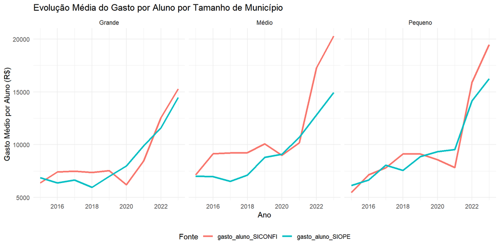

```r
# Média por ano e tamanho
dados_long_tamanho <- dados_long %>%
  group_by(ano, tamanho, Fonte) %>%
  summarise(Gasto_Medio = mean(Gasto_por_Aluno, na.rm = TRUE)) %>%
  ungroup()

ggplot(dados_long_tamanho, aes(x = ano, y = Gasto_Medio, color = Fonte, group = Fonte)) +
  geom_line(linewidth = 1.2) +
  facet_wrap(~ tamanho) +
  labs(
    title = "Evolução Média do Gasto por Aluno por Tamanho de Município",
    x = "Ano",
    y = "Gasto Médio por Aluno (R$)",
    color = "Fonte"
  ) +
  theme_minimal() +
  theme(legend.position = "bottom")
```

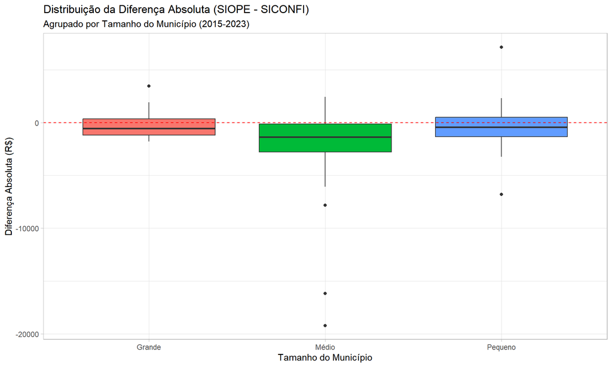

```r
ggplot(dados, aes(x = tamanho, y = diff_abs, fill = tamanho)) +
  geom_boxplot(show.legend = FALSE) +
  geom_hline(yintercept = 0, linetype = "dashed", color = "red") + # Linha de referência (diferença zero)
  labs(
    title = "Distribuição da Diferença Absoluta (SIOPE - SICONFI)",
    subtitle = "Agrupado por Tamanho do Município (2015-2023)",
    x = "Tamanho do Município",
    y = "Diferença Absoluta (R$)"
  ) +
  theme_light()
```

#### 5.2.1. Gráfico: Distribuição da Diferença Percentual por Tamanho (Violin)

O gráfico de violino é uma alternativa ao boxplot que também mostra a “forma” da distribuição (onde os dados estão mais concentrados). Aqui, usamos a `diff_perc` para complementar o boxplot da `diff_abs`.

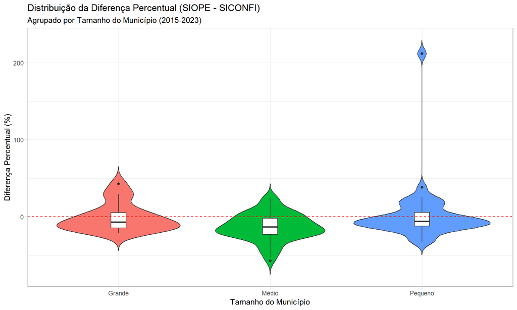

```r
ggplot(dados, aes(x = tamanho, y = diff_perc, fill = tamanho)) +
  geom_violin(trim = FALSE, show.legend = FALSE) +
  geom_boxplot(width = 0.1, fill = "white", show.legend = FALSE) + # Adiciona um mini-boxplot dentro
  geom_hline(yintercept = 0, linetype = "dashed", color = "red") +
  labs(
    title = "Distribuição da Diferença Percentual (SIOPE - SICONFI)",
    subtitle = "Agrupado por Tamanho do Município (2015-2023)",
    x = "Tamanho do Município",
    y = "Diferença Percentual (%)"
  ) +
  theme_light()
```